# Series02-Rstudio :

# 2 Statistical tests: comparison of medians (or means?)

In this series of exercises, you will explore how to compare two groups of data, using non-parametric tests (or parametric tests… if it makes sense to do so).

## 2.1 Make clear what is a statistical test, and when to use it.

Below are some questions to guide your analysis. You can answer them in your notebook, with a short sentence for each question.

```
    - What is a median? A mean?
```

Median: the middle value of a dataset when the values are ordered. Mean: the sum of all values divided by the number of values.

Dodge, 1993.Dodge Y.: Statistique. Dictionnaire encyclopédique. In(eds): . Paris: Dunod, 1993.

```
    - What is a variance? A standard deviation?
```

Variance: the average of the squared differences from the mean. Standard deviation (SD): the square root of the variance, expressing variability in the same units as the data.

Dodge, 1993.Dodge Y.: Statistique. Dictionnaire encyclopédique. In(eds): . Paris: Dunod, 1993.

```
    - What is a normal distribution?
```

(Gaussian distribution) is a symmetric, bell-shaped probability distribution defined by its mean (µ) and standard deviation (σ).

Dodge, 1993.Dodge Y.: Statistique. Dictionnaire encyclopédique. In(eds): . Paris: Dunod, 1993.

```
    - What is a statistical test?
```

A statistical test is a formal procedure that uses data to evaluate a hypothesis, typically by comparing an observed statistic to a theoretical distribution under the null hypothesis.

```
    - When to use a statistical test?
```

When you want to make inferences from a sample to a population, compare groups, or test relationships, instead of just describing the data.

```
    - What is a parametric test? A non-parametric test?
```

Parametric tests assume that data follow a certain distribution (usually normal) and use parameters like mean and variance (e.g., t-test, ANOVA). Non-parametric tests make fewer assumptions; they use ranks or medians (e.g., Wilcoxon, Kruskal-Wallis).

```
    - What are the assumptions of parametric tests?
```

Normal distribution of data (or residuals). Homogeneity of variances between groups. Independence of observations.

```
    - What are the assumptions of non-parametric tests?
```

Independence of observations. Ordinal or continuous data (not nominal). Monotonic relationship for correlation-type tests.

```
    - What is a p-value?
```

The p-value is the probability of obtaining results at least as extreme as those observed, assuming the null hypothesis is true.

```
    - What is the risk of error when using a statistical test?
```

Type I error (α): rejecting H0 when it is true (false positive). Type II error (β): failing to reject H0 when it is false (false negative).

```
    - What is the difference between a paired and an unpaired test?
```

Paired test: used when observations are linked (e.g., before–after on the same subjects). Unpaired test: used when observations are independent (e.g., two different groups).

Sources : Livres : Réussite à la LCA en français anglais Maitriser la LCA en anglais Dodge, 1993.Dodge Y.: Statistique. Dictionnaire encyclopédique. In(eds): . Paris: Dunod, 1993. Jenicek et Cleroux, 1982.Jenicek M., and Cleroux R.: Épidémiologie. In(eds): Principes, techniques, applications. Paris: Maloine, 1982. Jammal et coll., 1988.Jammal A., Allard R., and Loslier G.: Dictionnaire d’épidémiologie. In(eds): . St-Hyacinthe: Edisem, 1988.

You can use your favorite LLM, book or web site to answer these questions, but you have to provide at least one reference for each answer (book, article, URL, LLM prompt, etc.).

## 2.2 Effect of treatment over time

This is a very classical question in clinical or sport research: does a treatment-training have an effect over time?

To answer this question scientifically, measurements must be taken before and after treatment, and possibly later, in order to assess whether the effect is lasting or not.

### 2.2.1 The data

Download the file PrePost.csv

This file contains before/after measurements. The treatment is a rehabilitation training for individuals with cardiac conditions.

```r
prepost <- read.csv("data/Prepost.csv", sep=",", header=TRUE)
head(prepost)
```

|  | perf | time |
| --- | --- | --- |
| 1 | 125 | Before |
| 2 | 130 | Before |
| 3 | 132 | Before |
| 4 | 135 | Before |
| 5 | 136 | Before |
| 6 | 138 | Before |

```r
summary(prepost)
```

```
##       perf           time
##  Min.   :125.0   Length:16
##  1st Qu.:132.0   Class :character
##  Median :136.0   Mode  :character
##  Mean   :136.4
##  3rd Qu.:140.2
##  Max.   :148.0
```

Make a table, with one row per variable, and the following columns:

[output not shown]

### 2.2.2 The analysis

You want to know if the treatment has an effect on one or more of the measured variables.

- Does the treatment have an effect? H0 (null hypothesis): There is no difference between Before and After performance. H1 (alternative hypothesis): The After performance is higher than Before.
- What comparison are you going to make? We need to compare the same patient Before and after rehab.
- Which test will you use? Parametric or non-parametric? We can use a parametric test if we have a normal distribution. For check this we can use a Shapiro test to validate the normal distribution of our population. If we have non normal distribution we need to use a non parametric test.
- Which graph illustrates the effect of the treatment? We can use a paired line plot.

Here, we will test stereotypes about snorers… among others.

### 2.2.3 The data

Download the file snore.txt

```r
snore_df <- read.csv("data/snore.csv", sep = ";", dec = ",", header = TRUE)
head(snore_df)
```

|  | age | weight | height | alcool | sex | snore | tabac | IMC |
| --- | --- | --- | --- | --- | --- | --- | --- | --- |
| 1 | 47 | 71 | 158 | 0 | H | N | O | 28.44095 |
| 2 | 56 | 58 | 164 | 7 | H | O | N | 21.56454 |
| 3 | 46 | 116 | 208 | 3 | H | N | O | 26.81213 |
| 4 | 70 | 96 | 186 | 3 | H | N | O | 27.74887 |
| 5 | 51 | 91 | 195 | 2 | H | O | O | 23.93162 |
| 6 | 46 | 98 | 188 | 0 | F | N | N | 27.72748 |

```r
summary(snore_df)
```

```
##       age            weight           height          alcool
##  Min.   :23.00   Min.   : 42.00   Min.   :158.0   Min.   : 0.00
##  1st Qu.:43.00   1st Qu.: 77.00   1st Qu.:166.0   1st Qu.: 0.00
##  Median :52.00   Median : 95.00   Median :186.0   Median : 2.00
##  Mean   :52.27   Mean   : 90.41   Mean   :181.1   Mean   : 2.95
##  3rd Qu.:62.25   3rd Qu.:107.00   3rd Qu.:194.0   3rd Qu.: 4.25
##  Max.   :74.00   Max.   :120.00   Max.   :208.0   Max.   :15.00
##      sex               snore              tabac                IMC
##  Length:100         Length:100         Length:100         Min.   :16.20
##  Class :character   Class :character   Class :character   1st Qu.:27.56
##  Mode  :character   Mode  :character   Mode  :character   Median :28.07
##                                                           Mean   :27.22
##                                                           3rd Qu.:28.38
##                                                           Max.   :32.55
```

This file contains anthropometric and qualitative measurements (1 person per line).

### 2.2.4 The analysis

Do the data confirm the following stereotypes? Provide a reasoned answer (data, figure, result sentence) for each question. Are snorers fatter?

# 3 Make a histogram of weight for snorers and non-snorers (O=yes, N=no)

```r
names(snore_df)
```

```
## [1] "age"    "weight" "height" "alcool" "sex"    "snore"  "tabac"  "IMC"
```

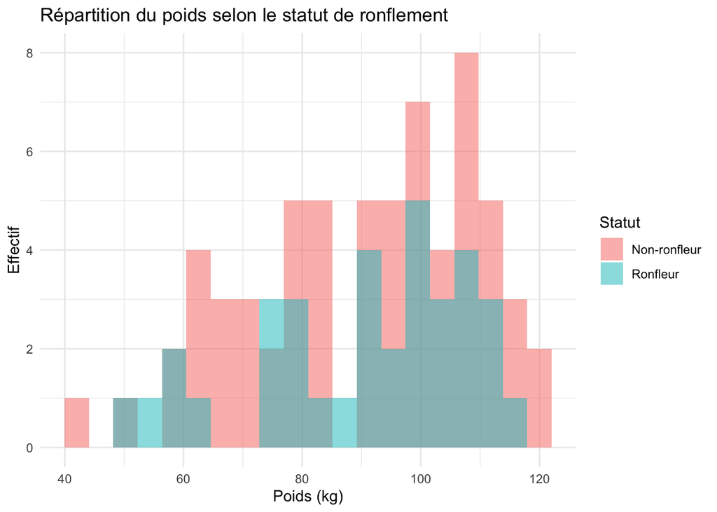

```r
snore_df$snore <- factor(snore_df$snore, levels = c("N","O"),
                         labels = c("Non-ronfleur","Ronfleur"))

# Plot
library(ggplot2)
ggplot(snore_df, aes(x = weight, fill = snore)) +
  geom_histogram(position = "identity", bins = 20, alpha = 0.5, na.rm = TRUE) +
  labs(title = "Répartition du poids selon le statut de ronflement",
       x = "Poids (kg)", y = "Effectif", fill = "Statut") +
  theme_minimal()
```

```r
names(snore_df)
```

```
## [1] "age"    "weight" "height" "alcool" "sex"    "snore"  "tabac"  "IMC"
```

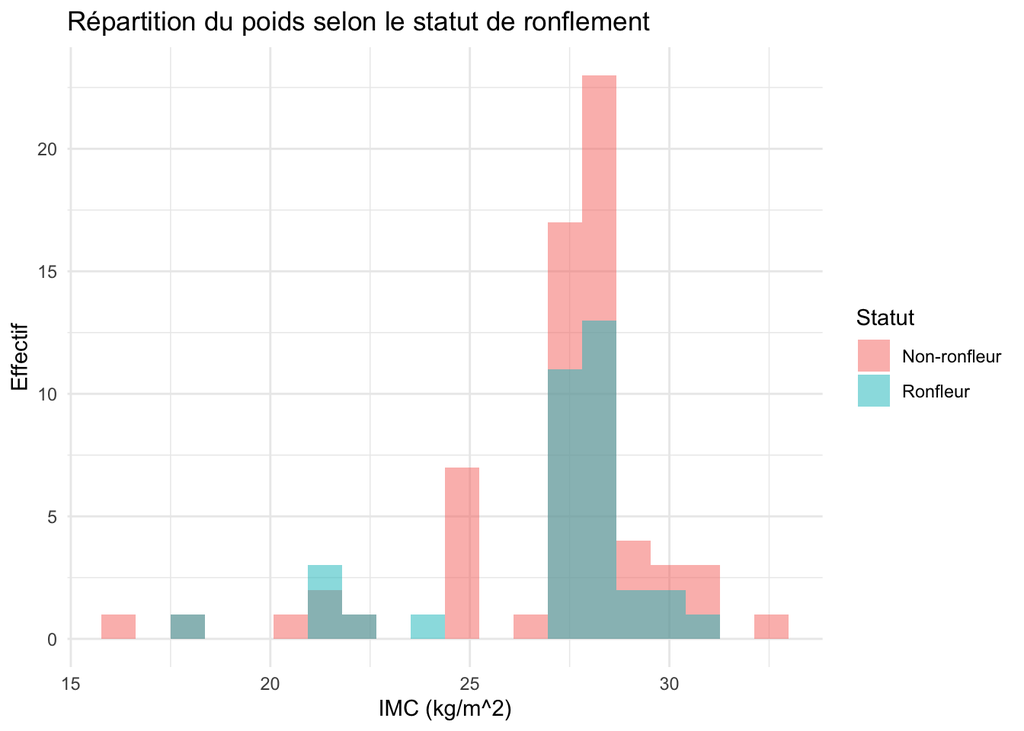

```r
# Plot
library(ggplot2)
ggplot(snore_df, aes(x = IMC, fill = snore)) +
  geom_histogram(position = "identity", bins = 20, alpha = 0.5, na.rm = TRUE) +
  labs(title = "Répartition du poids selon le statut de ronflement",
       x = "IMC (kg/m^2)", y = "Effectif", fill = "Statut") +
  theme_minimal()
```